# project_3

#### Clustering Definition

Clustering is an unsupervised machine learning technique used to group a set of objects in such a way that:

Objects in the same group (cluster) are more similar to each other,

And objects in different groups are more dissimilar.

🔷 Project Introduction: This project aims to segment Instagram users based on two main metrics:

Instagram visit score – reflecting user engagement.

Spending rank (0 to 100) – estimating how much users spend.

By applying clustering techniques like K-Means, Agglomerative Clustering, K-Medoids, and Hierarchical Clustering, the project identifies patterns in user behavior that can help target different user segments more effectively.

```python
import pandas as pd
import matplotlib.pyplot as plt
from sklearn.cluster import KMeans
from sklearn.preprocessing import StandardScaler
```

```python
data=pd.read_csv("C:/Users/Ravi/Downloads/Instagram visits clustering.csv")
data=data.drop('User ID',axis=1)
data.head()
```

|  | Instagram visit score | Spending_rank(0 to 100) |
| --- | --- | --- |
| 0 | 63 | 24.050708 |
| 1 | 61 | 25.223290 |
| 2 | 104 | 18.528245 |
| 3 | 82 | 86.890232 |
| 4 | 14 | 31.492397 |

Inference : The dataset is successfully loaded and cleaned by removing irrelevant identifiers (User ID). Only relevant features are retained.

Data includes numerical values showing a variety of Instagram engagement scores and corresponding spending ranks. This variation is essential for meaningful clustering.

```python
scaler=StandardScaler()
scaled_data=scaler.fit_transform(data)
```

Inference: StandardScaler is used to normalize the data. This ensures that all features contribute equally during distance-based clustering.

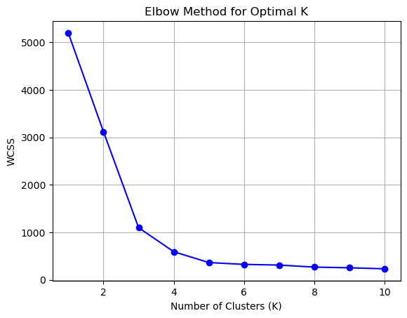

```python
wcss = []
K_range = range(1, 11)
for k in K_range:
    kmeans = KMeans(n_clusters=k, random_state=42)
    kmeans.fit(scaled_data)
    wcss.append(kmeans.inertia_)

plt.plot(K_range, wcss, 'bo-')
plt.title("Elbow Method for Optimal K")
plt.xlabel("Number of Clusters (K)")
plt.ylabel("WCSS")
plt.grid()
plt.show()
```

Inference: The Elbow Plot helps determine the optimal number of clusters (K). The ‘elbow point’ likely indicates K=3 as a good choice.

```python
kmeans = KMeans(n_clusters=3, random_state=42)
data['Cluster'] = kmeans.fit_predict(scaled_data)
```

Inference: K-Means assigns each user to one of 3 clusters. These clusters reflect different combinations of Instagram activity and spending behavior.

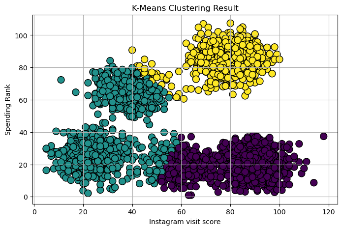

```
   Instagram visit score  Spending_rank(0 to 100)  Cluster
0                     63                24.050708        0
1                     61                25.223290        0
2                    104                18.528245        0
3                     82                86.890232        2
4                     14                31.492397        1
```

```python
plt.figure(figsize=(8, 5))
plt.scatter(data['Instagram visit score'], data['Spending_rank(0 to 100)'],
            c=data['Cluster'], cmap='viridis', s=100, edgecolor='k')
plt.title("K-Means Clustering Result")
plt.xlabel("Instagram visit score")
plt.ylabel("Spending Rank")
plt.grid()
plt.show()

print(data.head())
```

Inference: The scatter plot visually distinguishes 3 clusters. Users are grouped based on similarity in their visit scores and spending ranks.

```python
import pandas as pd
import random
import math
import matplotlib.pyplot as plt
```

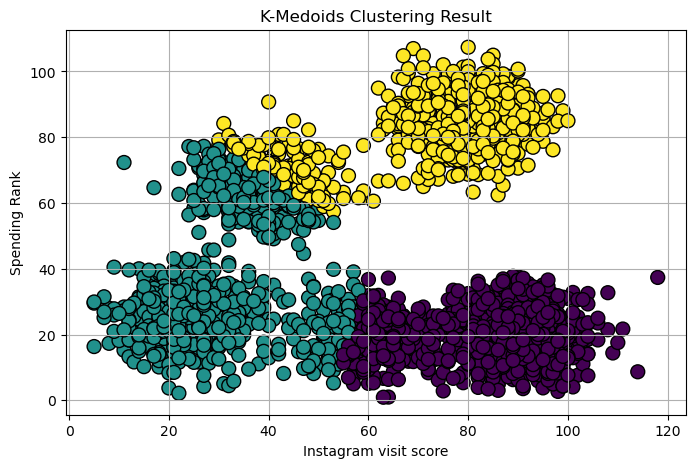

```
   User ID  Instagram visit score  Spending_rank(0 to 100)  Cluster
0        0                     63                24.050708        0
1        1                     61                25.223290        0
2        2                    104                18.528245        0
3        3                     82                86.890232        2
4        4                     14                31.492397        1
```

```python
# ---------- Step 1: Load data using pandas ----------
def load_data(file_path):
    df = pd.read_csv(file_path)
    data = df.iloc[:, 1:3].values.tolist()  # Use columns 1 and 2 (ignore ID)
    return df, data

# ---------- Step 2: Define helper functions ----------
def euclidean_distance(p1, p2):
    return math.sqrt(sum((x - y) ** 2 for x, y in zip(p1, p2)))

def total_cost(cluster, medoid):
    return sum(euclidean_distance(point, medoid) for point in cluster)

# ---------- Step 3: K-Medoids algorithm ----------
def k_medoids(data, k, max_iter=100):
    medoids = random.sample(data, k)

    for _ in range(max_iter):
        clusters = [[] for _ in range(k)]
        labels = []
        for point in data:
            distances = [euclidean_distance(point, medoid) for medoid in medoids]
            nearest_idx = distances.index(min(distances))
            clusters[nearest_idx].append(point)
            labels.append(nearest_idx)

        new_medoids = []
        for cluster in clusters:
            if not cluster:
                new_medoids.append(random.choice(data))
                continue
            min_cost = float('inf')
            best_medoid = cluster[0]
            for candidate in cluster:
                cost = total_cost(cluster, candidate)
                if cost < min_cost:
                    min_cost = cost
                    best_medoid = candidate
            new_medoids.append(best_medoid)

        if new_medoids == medoids:
            break
        medoids = new_medoids

    return medoids, clusters, labels

# ---------- Step 4: Run ----------
file_path = r"C:/Users/Ravi/Downloads/Instagram visits clustering.csv"
df, data_points = load_data(file_path)

k = 3
medoids, clusters, labels = k_medoids(data_points, k)

# Add cluster labels to original DataFrame
df['Cluster'] = labels

# ---------- Step 5: Plot ----------
plt.figure(figsize=(8, 5))
plt.scatter(df['Instagram visit score'], df['Spending_rank(0 to 100)'],
            c=df['Cluster'], cmap='viridis', s=100, edgecolor='k')
plt.title("K-Medoids Clustering Result")
plt.xlabel("Instagram visit score")
plt.ylabel("Spending Rank")
plt.grid()
plt.show()

# Preview labeled data
print(df.head())
```

Inference: K-Medoids is more robust to outliers compared to K-Means. This adds stability in segmentation when extreme values exist.

```python
import pandas as pd
from sklearn.preprocessing import StandardScaler
from sklearn.cluster import AgglomerativeClustering
from scipy.cluster.hierarchy import linkage,dendrogram
import matplotlib.pyplot as plt
import seaborn as sns
```

```python
data=pd.read_csv(r"C:/Users/Ravi/Downloads/Instagram visits clustering.csv")
data=data.drop('User ID',axis=1)
data.head()
```

|  | Instagram visit score | Spending_rank(0 to 100) |
| --- | --- | --- |
| 0 | 63 | 24.050708 |
| 1 | 61 | 25.223290 |
| 2 | 104 | 18.528245 |
| 3 | 82 | 86.890232 |
| 4 | 14 | 31.492397 |

```python
scaler = StandardScaler()
scaled_data = scaler.fit_transform(data)
```

```python
model = AgglomerativeClustering(n_clusters=3, linkage='ward')  # You can change linkage
data['Cluster'] = model.fit_predict(scaled_data)
```

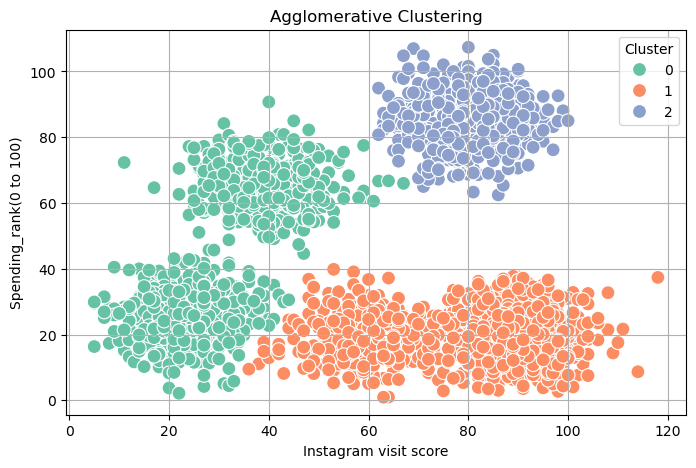

```python
plt.figure(figsize=(8, 5))
sns.scatterplot(
    x=data['Instagram visit score'],
    y=data['Spending_rank(0 to 100)'],
    hue=data['Cluster'],
    palette='Set2',
    s=100
)
plt.title("Agglomerative Clustering")
plt.grid(True)
plt.show()
```

Inference: Agglomerative clustering groups users hierarchically. Results may differ slightly from K-Means due to the bottom-up approach.

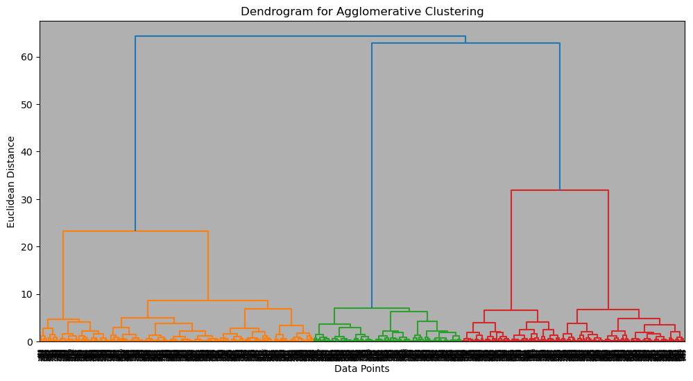

```python
linked = linkage(scaled_data, method='ward')  # 'ward' is commonly used
plt.figure(figsize=(12, 6))
dendrogram(linked,
           orientation='top',
           distance_sort='ascending',
           show_leaf_counts=True)
plt.title("Dendrogram for Agglomerative Clustering")
plt.xlabel("Data Points")
plt.ylabel("Euclidean Distance")
plt.grid(True)
plt.show()
```

Inference: The dendrogram provides a visual summary of hierarchical clustering. Clear divisions at certain heights confirm the presence of 3 distinct clusters.

```python
import numpy as np
import matplotlib.pyplot as plt
from scipy.cluster.hierarchy import dendrogram,linkage,fcluster
```

```python
data=pd.read_csv(r"C:/Users/Ravi/Downloads/Instagram visits clustering.csv")
data=data.drop('User ID',axis=1)
linked_single=linkage(data,method='single')
```

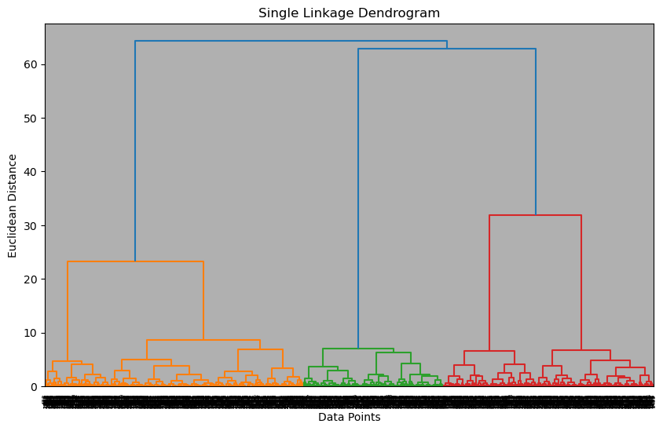

```python
plt.figure(figsize=(10, 6))
dendrogram(linked,
           orientation='top',
           distance_sort='ascending',
           show_leaf_counts=True)
plt.title("Single Linkage Dendrogram")
plt.xlabel("Data Points")
plt.ylabel("Euclidean Distance")
plt.grid(True)
plt.show()
```

```python
clusters_single = fcluster(linked_single, t=2, criterion='maxclust')
print("Sinlge Linkage Clusters:", clusters_single)
```

```
Sinlge Linkage Clusters: [1 1 1 ... 1 1 1]
```

```python
clusters_single
```

```
array([1, 1, 1, ..., 1, 1, 1], dtype=int32)
```

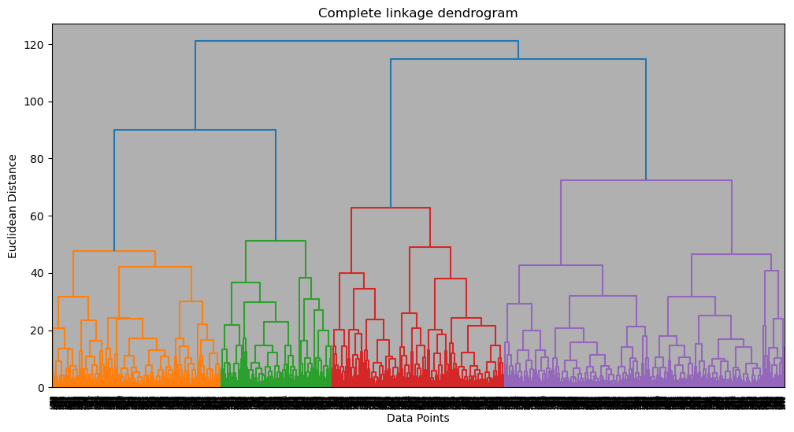

```python
data = pd.read_csv(r"C:/Users/Ravi/Downloads/Instagram visits clustering.csv")  # Replace with your actual file path
data = data.drop("User ID", axis=1)
# Perform Complete Linkage Clustering
linked_complete = linkage(data, method='complete')

linked = linked_complete
plt.figure(figsize=(12, 6))
dendrogram(linked,
           orientation='top',
           distance_sort='ascending',
           show_leaf_counts=True)
plt.title("Complete linkage dendrogram")
plt.xlabel("Data Points")
plt.ylabel("Euclidean Distance")
plt.grid(True)
plt.show()
```

Inference: Complete linkage clusters users based on the maximum distance between observations in pairs. This results in more compact clusters.

```python
clusters_complete = fcluster(linked_complete, t=2, criterion='maxclust')
print("Complete Linkage Clusters:", clusters_complete)
```

```
Complete Linkage Clusters: [2 2 2 ... 1 2 1]
```

🏁 Final Conclusion:

```
     The project successfully applied multiple clustering techniques on Instagram user data to identify 3 meaningful user segments based on their online behavior and spending. The use of standard scaling, elbow method, hierarchical clustering, and visualizations strengthens the analysis. These clusters can be leveraged in targeted marketing, recommendation engines, or personalization strategies.
```